# Predict If The Customer Claim the Car Insurance loan

Wenxin Jiang

March 19, 2023

## Introduction

### What Is Insurance Claim?

Car insurance claim is a request made by an insured customer to their insurance company to compensate them for financial losses incurred due to a car accident or theft. Claimants are usually policyholders who have purchased an insurance policy that covers their car.

### Why Perdict?

The prediction of whether a customer will claim a car insurance loan is critical for an insurance company, as it allows them to manage their risk effectively and avoid financial losses. Accurately predicting the outcome enables the insurance company to take appropriate measures to prevent fraudulent claims, to offer personalized policies that suit each customer’s needs, and to provide prompt and efficient services to the customers who need it the most. In this data analysis report, we aim to predict the likelihood of a customer claiming a car insurance loan based on the given background information, using various statistical and machine learning techniques.

### Our Dataset

Our dataset resembles practical world features of possible background info of car insurance policy holders, including age, gender, race, driving age, education, credit score, vehicle ownership number, vehicle year, marriage, children, region, annual mileage, vehicle type, speeding violations history, driving under the influence history, and past accidents are all factors that can influence the possibility of claiming a car insurance loan. (for detailed description of predictors, please check codebook in the zip file)

### Why Those Infomations Matter?

For instance, age, gender, and race can impact the likelihood of filing a claim. Younger drivers, particularly those under the age of 25, have been found to be more prone to accidents, which may lead to a higher chance of claiming an insurance loan. Similarly, male drivers have been found to be more likely to get into accidents and file a claim compared to female drivers. In terms of race, studies have shown that there may be disparities in car accident rates and insurance claims based on racial demographics.

Driving age, education, and credit score can also affect the likelihood of claiming an insurance loan. Drivers with a longer driving history may be less likely to file a claim, as they are likely to have more experience and safe driving habits. Additionally, higher education levels and credit scores are generally associated with more responsible driving behavior and may lead to fewer accidents and claims.

Vehicle ownership number and vehicle year can also influence the likelihood of claiming an insurance loan. Drivers who own more vehicles may have a higher chance of making a claim, as they have more assets to protect. Additionally, older vehicles may have more wear and tear and may be more prone to accidents, which may increase the likelihood of a claim.

Marital status and children may also impact the possibility of claiming an insurance loan. Married drivers may be more responsible and have a lower risk of getting into accidents, while drivers with children may drive more cautiously and avoid risky behavior.

The region and annual mileage of the driver can also impact the likelihood of making an insurance claim. Drivers in urban areas may have a higher chance of getting into accidents due to higher traffic volume, while drivers in rural areas may have more open roads and fewer accidents. Similarly, drivers who travel long distances frequently may be more likely to get into accidents.

The type of vehicle a driver owns and their history of speeding violations, driving under the influence, and past accidents may also influence the possibility of making an insurance claim. Vehicles with higher horsepower or those that are designed for speed may be more prone to accidents, while drivers with a history of traffic violations or past accidents may be more likely to file a claim.

Overall, these factors are important considerations for insurance companies when determining the likelihood of a claim and pricing insurance premiums.

## Loading Packages and Data

First, let’s load in all of our packages and the raw data.

```r
library(stats)
library(naniar)
library(xgboost)
library(vip)
library(tidymodels)
library(ISLR)
library(ISLR2)
library(tidyverse)
library(glmnet)
library(modeldata)
library(ggthemes)
library(janitor) # for naming conventions
library(naniar) # to assess missing data patterns
library(corrplot) # for a correlation plot
library(patchwork) # for putting plots together
library(rpart.plot)
library(forcats) # to grouping rarer class into one
library(dplyr) # to factorize variables
library(gridExtra) # to put multiple plots into one page
library(rsample) # to impute missing values
library(readr) # to read/write RDS files.
tidymodels_prefer()
```

```r
# Assigning the data to a variable
car <- read.csv("Car_Insurance_Claim.csv")

# Calling head() to see the first few rows
head(car)
```

```
##       ID   AGE GENDER     RACE DRIVING_EXPERIENCE   EDUCATION        INCOME
## 1 569520   65+ female majority               0-9y high school   upper class
## 2 750365 16-25   male majority               0-9y        none       poverty
## 3 199901 16-25 female majority               0-9y high school working class
## 4 478866 16-25   male majority               0-9y  university working class
## 5 731664 26-39   male majority             10-19y        none working class
## 6 877557 40-64 female majority             20-29y high school   upper class
##   CREDIT_SCORE VEHICLE_OWNERSHIP VEHICLE_YEAR MARRIED CHILDREN POSTAL_CODE
## 1    0.6290273                 1   after 2015       0        1       10238
## 2    0.3577571                 0  before 2015       0        0       10238
## 3    0.4931458                 1  before 2015       0        0       10238
## 4    0.2060129                 1  before 2015       0        1       32765
## 5    0.3883659                 1  before 2015       0        0       32765
## 6    0.6191274                 1   after 2015       0        1       10238
##   ANNUAL_MILEAGE VEHICLE_TYPE SPEEDING_VIOLATIONS DUIS PAST_ACCIDENTS OUTCOME
## 1          12000        sedan                   0    0              0       0
## 2          16000        sedan                   0    0              0       1
## 3          11000        sedan                   0    0              0       0
## 4          11000        sedan                   0    0              0       0
## 5          12000        sedan                   2    0              1       1
## 6          13000        sedan                   3    0              3       0
```

## Exploring and Tidying the Raw Data

### Variable Selection

```r
# Calling dim() to see how many rows and columns
dim(car)
```

```
## [1] 10000    19
```

The data set contains 10,000 rows and 19 columns. From 19 variables, outcome, is our response. And the rest of 18 variables are out potential predictors.

We can check the missing data by using vis_miss(). We can see that there is 1% data missing in total, which is about 10% each missing in CREDIT_SCORE and ANNUAL_MILEAGE.

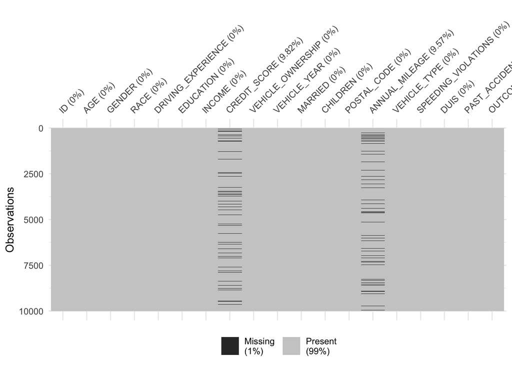

```r
# plot of missing values in the data
vis_miss(car)
```

One way we could choose to handle the missingness is to remove the variables with any missing data by simply excluding them.

Another way is to remove all observations with missing data from the data set, which is what geom_histogram() and mean() do by default. We could do that before we split the data like so:

```r
# car <- car %>% drop_na()
```

However, dropping those observations reduced the overall number of observations from 10000 to 8149, a reduction of approximately 18.51%, which is a fairly large reduction.

Instead of losing 18% of observations, later we when setting up recipe, we will instead use linear imputation to handle it since there is only 2 variables with missing data.

### Tidying the Data

Let’s drop the variables not be needed.

First of all, before hands on taking care of our dataset, we will clean the vairables’ name so that the column name can be easier to use. The column name are cleaned up to a consistent style of all lowercase and underscore.

```r
car <- clean_names(car)
names(car) # take a look at cleaned vairable names
```

```
##  [1] "id"                  "age"                 "gender"
##  [4] "race"                "driving_experience"  "education"
##  [7] "income"              "credit_score"        "vehicle_ownership"
## [10] "vehicle_year"        "married"             "children"
## [13] "postal_code"         "annual_mileage"      "vehicle_type"
## [16] "speeding_violations" "duis"                "past_accidents"
## [19] "outcome"
```

Also, keeping thousands of levels of value of predictor “postal_code” can be redundant. Let’s change variable ‘postal_code’ to ‘zipcode’. And only keep the regional number (the first number) to simplify the predictor. (check codebook for detail of regional number)

```r
car$zipcode <- as.numeric(substr(car$postal_code, 1, 1))
```

We will also change our response variable “outcome”, which is currently a binary variable, to be a factor. Besides, we will also change variables “zipcode”, “vehicle_ownership”, “married”, “children” to factors. These variables are numeric for now. We have to convert these variables to factors so machine will not learn these variables as quantitative.

```r
car <- car %>%
  mutate(outcome = factor(outcome),
         zipcode = factor(zipcode),
         vehicle_ownership = factor(vehicle_ownership),
         married =  factor(married),
         children =  factor(children))
```

Then, we will drop variables ‘id’, ‘race’, and ‘vehicle_type’. Identification number does not affect our outcome. ‘race’ and ‘vehicle_type’ contains over 90% of single class, so we will not bother analysis them.

```r
drops <- c('id', 'race', 'vehicle_type','postal_code')
car = car[,!(names(car) %in% drops)]
```

take a look at the final dataset.

```r
head(car)
```

```
##     age gender driving_experience   education        income credit_score
## 1   65+ female               0-9y high school   upper class    0.6290273
## 2 16-25   male               0-9y        none       poverty    0.3577571
## 3 16-25 female               0-9y high school working class    0.4931458
## 4 16-25   male               0-9y  university working class    0.2060129
## 5 26-39   male             10-19y        none working class    0.3883659
## 6 40-64 female             20-29y high school   upper class    0.6191274
##   vehicle_ownership vehicle_year married children annual_mileage
## 1                 1   after 2015       0        1          12000
## 2                 0  before 2015       0        0          16000
## 3                 1  before 2015       0        0          11000
## 4                 1  before 2015       0        1          11000
## 5                 1  before 2015       0        0          12000
## 6                 1   after 2015       0        1          13000
##   speeding_violations duis past_accidents outcome zipcode
## 1                   0    0              0       0       1
## 2                   0    0              0       1       1
## 3                   0    0              0       0       1
## 4                   0    0              0       0       3
## 5                   2    0              1       1       3
## 6                   3    0              3       0       1
```

Creating a final dataset csv.

```r
write.csv(car, "cleaned_data.csv", row.names = FALSE)
```

### Visual EDA

Now, we will explore the relationships between select variables with the outcome as well as with each other.

#### Who claimed the loan?

First, let’s explore the distribution of our outcome variable.

One important thing to note before diving deeper into building our models, is to realize that in real life, it is less customer to claim his/her loan, which sounds good for insurance company. Anyways, below we can see a plot of the distribution of if customers claimed his/her loan. As a reminder, a “1” for means a customer has claimed his/her loan else 0.

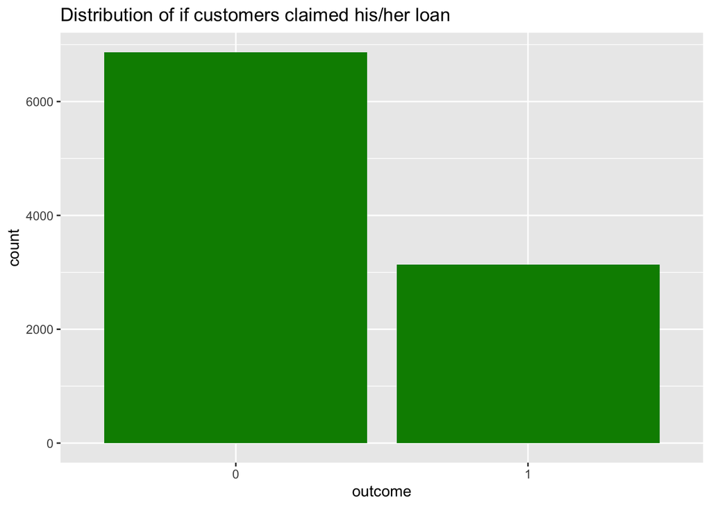

```r
# Distribution of customers who claimed his/her loan
ggplot(car, aes(outcome)) +
  geom_bar(fill='green4') +
  labs(
    title = "Distribution of if customers claimed his/her loan"
  )
```

As we can see, about 3000 customer claimed the loan and about 7000 customer didn’t. More observations in our dataset did not claim his/her loan.

#### Variable Correlation Plot

To get an idea of the relationships between our numeric variables, we’ll make a correlation matrix and then make a heat map of the correlation of these predictors.

from the correlation matrix, I am not surprised by the fact that speeding violations goes along with past accident and drug/drunk drive.

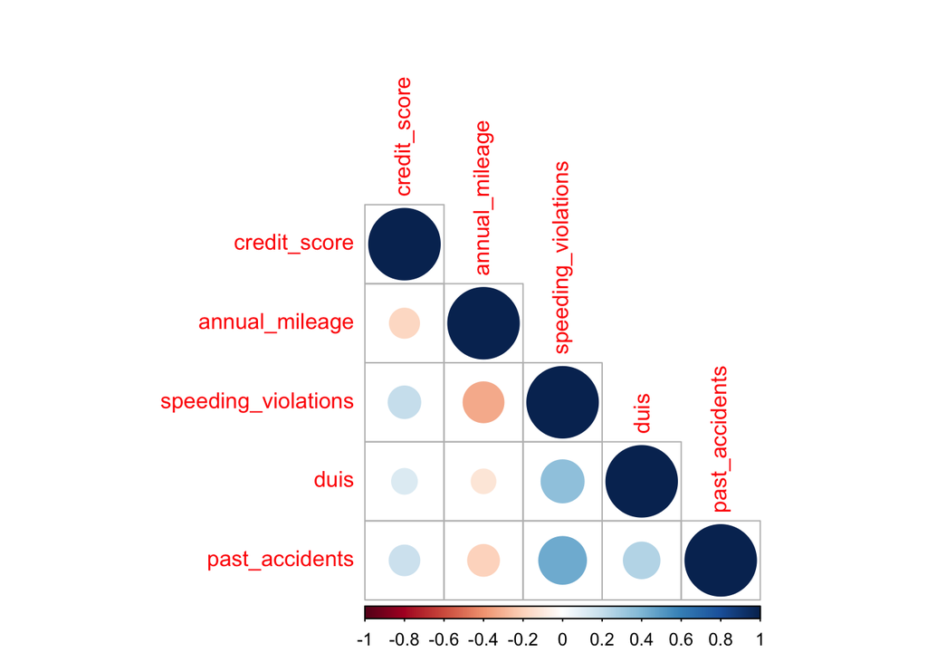

```r
# making a correlation matrix and heat map of the predictors
car %>%
  select(where(is.numeric)) %>%
  cor(use = "pairwise.complete.obs") %>%
  corrplot(type='lower')
```

#### Importance of Categorical Variables

Besides of quantitative variables, we will also take a look at categorical variables are see their relationship with Outcome. Create a percent stacked bar chart and see if they are good predictors.

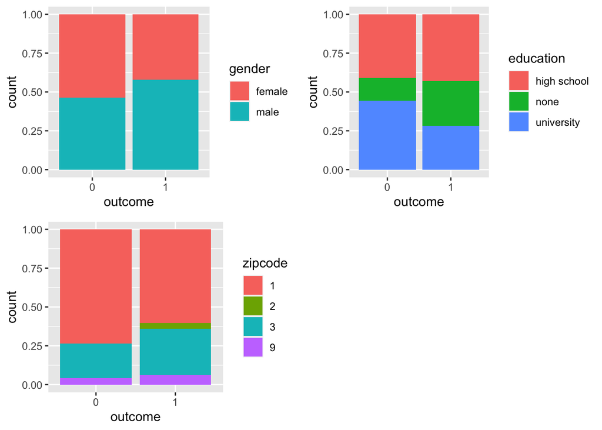

```r
age_distribution <- ggplot(car, aes(fill=age, x=outcome)) +
    geom_bar(position="fill")
gender_distribution <- ggplot(car, aes(fill=gender, x=outcome)) +
    geom_bar(position="fill")
driving_experience_distribution <- ggplot(car, aes(fill=driving_experience, x=outcome)) +
    geom_bar(position="fill")
education_distribution <- ggplot(car, aes(fill=education, x=outcome)) +
    geom_bar(position="fill")
income_distribution <- ggplot(car, aes(fill=income, x=outcome)) +
    geom_bar(position="fill")
vehicle_ownership_distribution <- ggplot(car, aes(fill=vehicle_ownership, x=outcome)) +
    geom_bar(position="fill")
year_distribution <- ggplot(car, aes(fill=vehicle_year, x=outcome)) +
    geom_bar(position="fill")
merriage_distribution <- ggplot(car, aes(fill=married, x=outcome)) +
    geom_bar(position="fill")
child_distribution <- ggplot(car, aes(fill=children, x=outcome)) +
    geom_bar(position="fill")
location_distribution <- ggplot(car, aes(fill=zipcode, x=outcome)) +
    geom_bar(position="fill")

# not good predictors
grid.arrange(gender_distribution,education_distribution,location_distribution,ncol=2)
```

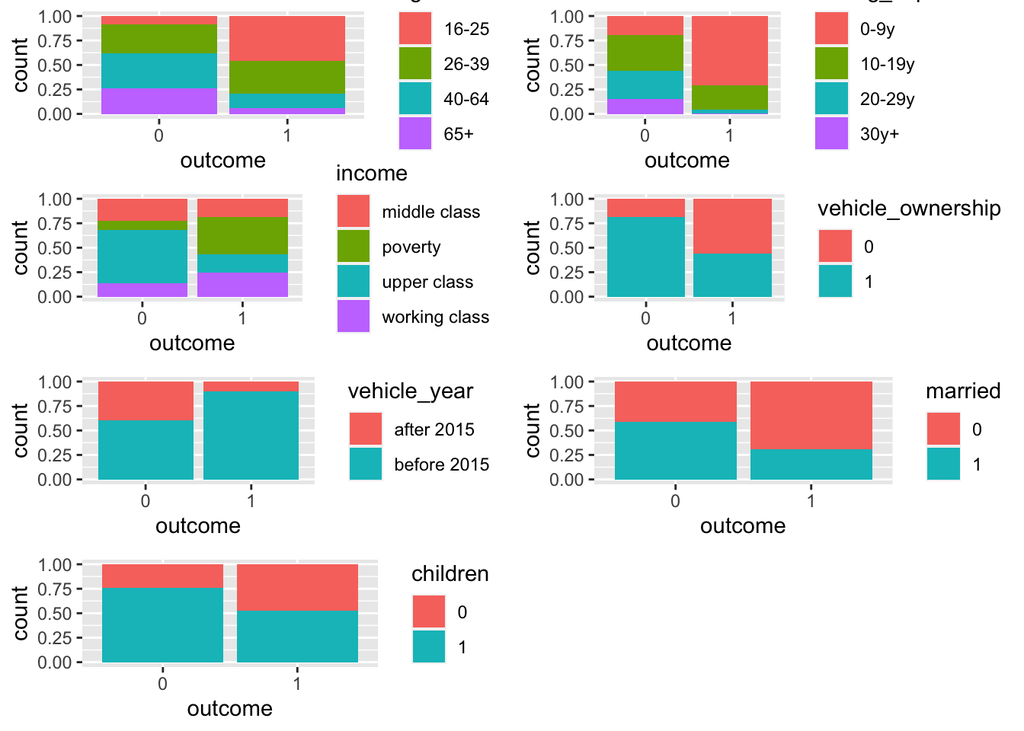

```r
# good predictors
grid.arrange(age_distribution, driving_experience_distribution, income_distribution,vehicle_ownership_distribution,year_distribution,merriage_distribution, child_distribution,ncol=2)
```

## Setting up models

Before we do any model building, we have to perform a training / testing split on our data. I decided to go with 80/20 for this data because the testing data set will still have a significant amount of observations, but our model has more to train on and learn. The reason we do this is because we want to avoid over-fitting that can only be fit once to deem how accurate our model truly is. We also set a random seed to ensure the training / testing split is the same set every time we go back and work on the following code. We stratify on our response variable, outcome, and we can move the chains right along.

### Train/Test Split

```r
set.seed(912)  # setting a seed so the split is the same
car_split <- car %>%
  initial_split(prop = 0.8, strata = "outcome")

car_train <- training(car_split) # training split
car_test <- testing(car_split) # testing split
```

### Recipe Building

Because we are going to be use the same predictors, model conditions, and response variable, we create one central recipe for all of our models to work with. Each model takes in a unique recipe but works with it under different circumstances. We only used 12 of the 15 predictor variables, excluding gender, education, location as explained in ‘Importance of Categorical Variables’ tab. We will dummy categorical variables, and center and scale our data for model usage.

```r
car_recipe <-   # building the recipe to be used for each model
  recipe(outcome ~
           age+income+married+duis+credit_score+children+past_accidents+driving_experience+vehicle_ownership+
           vehicle_year+annual_mileage+speeding_violations,
         data = car_train) %>%
  step_impute_linear(annual_mileage, impute_with = imp_vars(age, income, married, duis, children, past_accidents, driving_experience, vehicle_ownership,
           vehicle_year, speeding_violations)) %>%
    step_impute_linear(annual_mileage, impute_with = imp_vars(age, income, married)) %>%
  step_impute_linear(credit_score) %>%

  step_dummy(age, driving_experience, income,
             vehicle_ownership, vehicle_year, married, children) %>%  # dummy predictor on categorical variables
  step_center(all_predictors()) %>%   # standardizing our predictors
  step_scale(all_predictors())

prep(car_recipe)
```

```
## Recipe
##
## Inputs:
##
##       role #variables
##    outcome          1
##  predictor         12
##
## Training data contained 7999 data points and 1470 incomplete rows.
##
## Operations:
##
## Linear regression imputation for annual_mileage [trained]
## Linear regression imputation for annual_mileage [trained]
## Linear regression imputation for credit_score [trained]
## Dummy variables from age, driving_experience, income, vehicle_ownership, vehic... [trained]
## Centering for duis, credit_score, past_accidents, annual_mile... [trained]
## Scaling for duis, credit_score, past_accidents, annual_mile... [trained]
```

### K-Fold Cross Validation

K-fold cross validation is done by splitting the data into k folds as described above with each fold being a testing set with the other k-1 folds being the training set for that fold. Then, whichever model we are fitting is fit to each training set and tested on the corresponding testing set (each time, a different fold should be used as a validation set). Then, the average accuracy is taken from the testing set of each of the folds to measure performance (other metrics can be taken as well such as standard error).

We use k-fold cross validation rather than simply fitting and testing models on the entire training set because cross validation provides a better estimate of the testing accuracy. It is better to take the mean accuracy from several samples instead of just one accuracy from one sample because, as n increases, we reduce variation.

```r
car_folds <- vfold_cv(car_train, v = 5, strata = outcome)  # 5-fold CV
```

Save the folds, recipe, training and testing dataset for later

```r
save(car_folds, car_recipe, car_train, car_test, file = "/Users/wenxinjiang/Desktop/PSTAT 131/Wenxin 131project/CAR-Modeling-Setup.rda")
```

## Model Building

It is now time to build our models! Since the models take a very long time to run, the results from each of the models has been saved to avoid rerunning the models every time. I have chosen area under the roc curve ‘roc_auc’ as my metric because it works as an overall metric for all models. The ‘roc_auc’ is one of the most commonly used measures for evaluating the performance of classification models. A higher roc_auc is better Also, I have fit 4 models to the car insurance data; however, we will only be conducting further analysis on the best-performing model. Let’s get to building our models!

### Fitting the models

Each of the models had a very similar process.

I outlined how to build the models under that step (however, the code will not be shown here to save time, for detailed process, please check file ‘fitting_models.r’).

For each of the models, you must conduct these steps to fit them:

1. Set up the model by specifying what type of model, setting its engine, and setting its mode (which was always classification)
2. Set up the workflow for the model and add the model and the recipe.
3. Create a tuning grid to specify the ranges of the parameters you wish to tune as well as how many levels of each.
4. Tune the model and specify the workflow, k-fold cross validation folds, and the tuning grid for our chosen parameters to tune.
5. Save the tuned models to an RDS file to avoid rerunning the model.
6. Load back in the saved files.

```r
# read_rds() to load back in

# logistic REGRESSION
logreg_fited <- read_rds(file = "/Users/wenxinjiang/Desktop/PSTAT 131/Wenxin 131project/tuned_models/logreg.rda")

# K NEAREST NEIGHBORS
knn_tuned <- read_rds(file = "/Users/wenxinjiang/Desktop/PSTAT 131/Wenxin 131project/tuned_models/knn.rda")

# ELASTIC NET
en_tuned <- read_rds(file = "/Users/wenxinjiang/Desktop/PSTAT 131/Wenxin 131project/tuned_models/en.rda")

# RANDOM FOREST
rf_tuned <- read_rds(file = "/Users/wenxinjiang/Desktop/PSTAT 131/Wenxin 131project/tuned_models/rf.rda")
```

7. Collect the metrics of the tuned models, arrange in ascending order of mean to see what the highest ROC_AUC for that tuned model is, and slice to choose only the highest ROC_AUC. Save the ROC_AUC to a variable for comparison.

## Model Results

It’s finally time to compare the results of all of our models and see which ones performed the best!

```r
# Creating a tibble of all the models and their RMSE
final_compare_tibble <- tibble(Model = c("Logistic Regression", "K Nearest Neighbors", "Elastic Net", "Random Forest"), ROC_AUC = c(logreg_auc$mean, knn_auc$mean, en_auc$mean, rf_auc$mean))

# Arranging by lowest ROC_AUC
final_compare_tibble <- final_compare_tibble %>%
  arrange(desc(ROC_AUC))

final_compare_tibble
```

```
## # A tibble: 4 × 2
##   Model               ROC_AUC
##   <chr>                 <dbl>
## 1 Elastic Net           0.889
## 2 Logistic Regression   0.889
## 3 Random Forest         0.884
## 4 K Nearest Neighbors   0.857
```

From the performance of the models on the cross-validation data, we can see that the Elastic Net model performed the best.

## Results of the Best Model

### Performance on the Folds

So, the Elastic Net performed the best out of all 4 of our models. But which tuned parameters were chosen as the best Elastic Net model?

```r
en_auc
```

```
## # A tibble: 1 × 8
##        penalty mixture .metric .estimator  mean     n std_err .config
##          <dbl>   <dbl> <chr>   <chr>      <dbl> <int>   <dbl> <chr>
## 1 0.0000000001       1 roc_auc binary     0.889     5 0.00192 Preprocessor1_Mod…
```

Elastic Net #91 with penalty 1e-10 and mixture of 1 performed the best with an ROC_AUC of 0.8887358!

### Fitting to Training Data

Now, we will take that best model from the tuned elastic net and fit it to the training data. This will train that elastic net one more time on the entire training data set. We will use finalize_workflow() and fit() to fit your chosen model to the entire training set. Once we have fit and trained the elastic net on the training data, it will be ready for testing!

```r
# load back saved workflow
en_wf <- read_rds(file = "/Users/wenxinjiang/Desktop/PSTAT 131/Wenxin 131project/tuned_models/en_wflow.rda")

final_wf<- finalize_workflow(en_wf, en_auc)

en_final<- fit(final_wf, car_train)
```

### Testing the Model

Now, it’s time to test our elastic net model to see how it performs on data that it has not been trained on at all: the testing data set. we will use augment() to assess the performance of the chosen model on the testing set

```r
augment(en_final, new_data = car_test) %>%
  roc_auc(outcome, estimate = .pred_0)
```

```
## # A tibble: 1 × 3
##   .metric .estimator .estimate
##   <chr>   <chr>          <dbl>
## 1 roc_auc binary         0.898
```

Our elastic net actually performed better on the testing set than on the cross-validation folds with a roc_auc of 0.8983439! We can say our model did pretty good! A AUC value around 0.9 is generally considered a excellent result.

## Conclusion

Throughout this project, we have researched, explored, and analyzed our data and its variables in order to build and test a model that could predict if a customer would claim his/her loans. After diligent analysis, testing, and computing, we can say that the Elastic Net model was the best at predicting. Unfortunately, this model was not perfect, and leaves room for improvement.

The model that did the worst was K Nearest Neighbors (KNN). This was also not surprising as KNN tends to do worse when there are too many predictors because this means the data has too many dimensions. In a high dimensional data space, the data points are not close enough to each other for KNN to do well in predicting the outcome unless there are enough observations to make up for the high dimensional data space. Therefore, it makes sense that KNN did the worst.

Some avenues of improvement may be to look into possible correlation between numeric and categorical. If I were to continue this project and move forward with my analysis, I would like to explore more real world data that may not be designed to be balanced as what we have now. Overall, attempting to predict if a customer would claim his/her loans using this data set provided great opportunity for me to build my machine learning and data analysis skills.

As I got to know the data set more, I found myself becoming more passionate about learning everything about my data and finding a model that would work the best. Although the elastic net might not have been perfect, I am glad I was able to develop a model that at least explains some of the variation!

## Sources

This data was taken from the Kaggle data set, “Car Insurance Data - Insurance Claims over Cars”, (https://www.kaggle.com/datasets/sagnik1511/car-insurance-data/code?resource=download).